# Yurt Dışında Otel Açılacak En Uygun Ülke Analizi

**Yazar:** Öykü Kaya **Numara:** 24litt035 **Ders:** Veri Analizinde Bilgisayar Programlama 2 **Tarih:** 7 Haziran 2026 **Veri Seti:** Kaggle — Hotel Booking Demand Dataset

## Analiz Amacı

Bu çalışmada amacım yurt dışında bir otel açmak isteyen birinin hangi ülkede daha kârlı olabileceğini, Kaggle'daki *Hotel Booking Demand* veri seti üzerinden anlamaya çalışmak. Veri setinde 2015-2017 yılları arasında iki farklı otele yapılan 120 bin rezarvasyon vardır. Bu çalışmada analiz süresini kısaltmak amacıyla veri setinin daha az örneğini kullanarak müşterilerin geldiği ülkelere göre rezervasyon sayısı, iptal oranı, ortalama günlük gelir (ADR) ve ortalama kalış süresi gibi ölçüleri çıkarıp karşılaştırdım.

## 1. Veri Seti Hakkında

**Bu analiz için önemli sütunlar:**

- `country`: Rezervasyonu yapan müşterinin ülke kodu (ISO 3 harfli).
- `is_canceled`: Rezervasyon iptal edildi mi (0 / 1).
- `adr`: Average Daily Rate — günlük ortalama oda geliri.
- `stays_in_weekend_nights`, `stays_in_week_nights`: Hafta sonu ve hafta içi kalınan gece sayısı.
- `hotel`: Otelin tipi (City / Resort).
- `lead_time`: Rezervasyon ile kalış arasındaki gün sayısı.

## 2. Veri Yükleme ve İlk Bakış

```python
import pandas as pd
import numpy as np
import matplotlib.pyplot as plt
import seaborn as sns

sns.set_style("whitegrid")
plt.rcParams["figure.figsize"] = (10, 5)
pd.set_option("display.max_columns", None)

df = pd.read_csv("hotel_bookings.csv")
df.head()
```

[output not shown]

```python
print("Boyut:", df.shape)
print("Sütun sayısı:", df.shape[1])
```

```
Boyut: (30000, 24)
Sütun sayısı: 24
```

```python
df.dtypes
```

```
hotel                              str
is_canceled                      int64
lead_time                        int64
arrival_date_year                int64
arrival_date_month                 str
stays_in_weekend_nights          int64
stays_in_week_nights             int64
adults                           int64
children                       float64
babies                           int64
meal                               str
country                            str
market_segment                     str
distribution_channel               str
is_repeated_guest                int64
previous_cancellations           int64
reserved_room_type                 str
booking_changes                  int64
deposit_type                       str
customer_type                      str
adr                            float64
required_car_parking_spaces      int64
total_of_special_requests        int64
reservation_status                 str
dtype: object
```

## 3. Veri Temizliği

Veri setinde `country` sütununda az sayıda eksik değer var. Bu analiz tamamen ülke bazlı olduğu için ülkesi belli olmayan satırları çıkardım. `children` sütunundaki birkaç eksik değeri de 0 ile doldurdum (anlamlı bir tahmin yapmak mümkün değil, kayıp sayısı zaten çok az).

```python
# Eksik veri kontrolü
df.isnull().sum()[df.isnull().sum() > 0]
```

```
children      8
country     122
dtype: int64
```

```python
# Ülkesi belli olmayan satırları çıkardık
df = df.dropna(subset=["country"]).copy()
df["children"] = df["children"].fillna(0)
print("Temizlikten sonra boyut:", df.shape)
```

```
Temizlikten sonra boyut: (29878, 24)
```

```python
df["toplam_gece"] = df["stays_in_weekend_nights"] + df["stays_in_week_nights"]
df[["stays_in_weekend_nights", "stays_in_week_nights", "toplam_gece"]].head()
```

|  | stays_in_weekend_nights | stays_in_week_nights | toplam_gece |
| --- | --- | --- | --- |
| 0 | 1 | 1 | 2 |
| 1 | 2 | 2 | 4 |
| 2 | 1 | 1 | 2 |
| 3 | 3 | 1 | 4 |
| 4 | 0 | 5 | 5 |

## 4. Tanımsal İstatistikler

Önce genel analiz yapılacak daha sonra ülkeler incelenceektir.

### 4.1. Sayısal sütunların genel özeti

```python
df[["lead_time", "adr", "toplam_gece", "adults"]].describe().round(2)
```

|  | lead_time | adr | toplam_gece | adults |
| --- | --- | --- | --- | --- |
| count | 29878.00 | 29878.00 | 29878.00 | 29878.00 |
| mean | 99.32 | 112.76 | 4.14 | 1.89 |
| std | 71.30 | 60.63 | 2.19 | 0.54 |
| min | 0.00 | 0.00 | 0.00 | 1.00 |
| 25% | 47.00 | 69.03 | 3.00 | 2.00 |
| 50% | 83.00 | 103.46 | 4.00 | 2.00 |
| 75% | 134.00 | 146.28 | 5.00 | 2.00 |
| max | 647.00 | 473.74 | 14.00 | 4.00 |

### 4.2. Otel tipine göre frekans

```python
df["hotel"].value_counts()
```

```
hotel
City Hotel      20002
Resort Hotel     9876
Name: count, dtype: int64
```

```python
df["hotel"].value_counts(normalize=True).round(3) * 100
```

```
hotel
City Hotel      66.9
Resort Hotel    33.1
Name: proportion, dtype: float64
```

Veri ağırlıklı olarak City Hotel ağırlıklı.Bu yüzden analizde her iki oteli birlikte değerlendirecağiz aynı zamanda otel tipi etkisini de ayrıca kontrol edeceğiz.

### 4.3. Genel iptal oranı

```python
iptal_orani = df["is_canceled"].mean()
print(f"Genel iptal oranı: %{iptal_orani*100:.1f}")
```

```
Genel iptal oranı: %38.0
```

Yaklaşık her 10 rezervasyondan 4'ü iptal ediliyor. Bu otelcilik sektörü için yüksek bir oran. Bu yüzden iptal oranı, ülke karşılaştırmasında bizim için kritik bir kriter olacak.

### 4.4. En çok rezervasyon yapan ilk 10 ülke

```python
top10 = df["country"].value_counts().head(10)
top10
```

```
country
PRT      12033
GBR       3005
FRA       2559
ESP       2190
DEU       1802
Diger     1040
ITA        975
IRL        837
BEL        635
BRA        548
Name: count, dtype: int64
```

Görüldüğü gibi rezervasyonların büyük çoğunluğu Portekiz'den geliyor. Bunun nedeni veri setinin Portekiz'deki otellere ait olmasıdır. Çünkü yerli müşteri zaten en büyük paydır. Yurt dışından gelen müşteri yoğunluğu açısından İngiltere, Fransa, İspanya ve Almanya öne çıkıyor.

### 4.5. Ülkelere göre gruplandırılmış istatistikler

En çok rezervasyon yapan ilk 10 ülkeyi alıp her biri için ortalama ADR, ortalama gece sayısı, iptal oranı ve toplam rezervasyon sayısını analiz edersek:

```python
top10_ulke = df["country"].value_counts().head(10).index.tolist()
df_top = df[df["country"].isin(top10_ulke)]

ulke_ozet = df_top.groupby("country").agg(
    rezervasyon_sayisi=("is_canceled", "count"),
    iptal_orani=("is_canceled", "mean"),
    ortalama_adr=("adr", "mean"),
    ortalama_gece=("toplam_gece", "mean"),
).round(3).sort_values("rezervasyon_sayisi", ascending=False)

ulke_ozet
```

| country | rezervasyon_sayisi | iptal_orani | ortalama_adr | ortalama_gece |
| --- | --- | --- | --- | --- |
| PRT | 12033 | 0.551 | 106.758 | 4.110 |
| GBR | 3005 | 0.183 | 120.467 | 4.169 |
| FRA | 2559 | 0.186 | 121.284 | 4.128 |
| ESP | 2190 | 0.289 | 107.653 | 4.223 |
| DEU | 1802 | 0.162 | 123.923 | 4.133 |
| Diger | 1040 | 0.362 | 112.407 | 4.163 |
| ITA | 975 | 0.468 | 109.070 | 4.138 |
| IRL | 837 | 0.240 | 115.483 | 4.165 |
| BEL | 635 | 0.195 | 111.190 | 4.198 |
| BRA | 548 | 0.376 | 102.706 | 4.000 |

Tablodaki en dikkat çekici şey, Portekiz'in iptal oranının %50'nin üzerinde olması. Almanya, İngiltere ve Fransa için bu oran çok daha düşük. ADR (günlük gelir) ise ülkeler arasında çok farklılıklar göstermiyor ama yine de bazı ülkeler az da olsa öne çıkıyor.

### 4.6. Korelasyon

Sayısal değişkenler arasındaki ilişkileri analiz edersek:

```python
sayisal = ["lead_time", "adr", "toplam_gece", "adults", "is_canceled",
           "total_of_special_requests", "booking_changes"]
df[sayisal].corr().round(2)
```

|  | lead_time | adr | toplam_gece | adults | is_canceled | total_of_special_requests | booking_changes |
| --- | --- | --- | --- | --- | --- | --- | --- |
| lead_time | 1.00 | 0.00 | 0.01 | 0.00 | 0.00 | -0.00 | 0.00 |
| adr | 0.00 | 1.00 | 0.01 | 0.00 | -0.03 | 0.01 | -0.00 |
| toplam_gece | 0.01 | 0.01 | 1.00 | 0.00 | 0.00 | 0.00 | 0.01 |
| adults | 0.00 | 0.00 | 0.00 | 1.00 | 0.00 | -0.00 | 0.01 |
| is_canceled | 0.00 | -0.03 | 0.00 | 0.00 | 1.00 | -0.00 | 0.01 |
| total_of_special_requests | -0.00 | 0.01 | 0.00 | -0.00 | -0.00 | 1.00 | -0.01 |
| booking_changes | 0.00 | -0.00 | 0.01 | 0.01 | 0.01 | -0.01 | 1.00 |

## 5. Görselleştirmeler

### 5.1. ADR Dağılımı (Histogram)

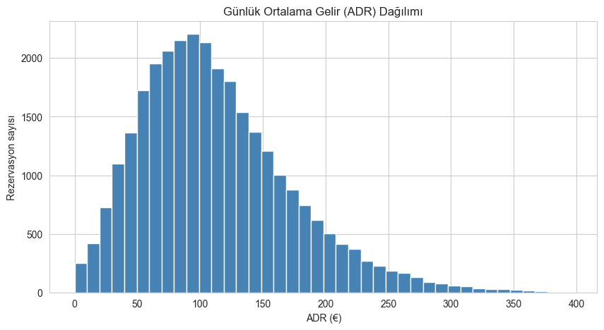

```python
fig, ax = plt.subplots(figsize=(10, 5))
df[df["adr"] < 400]["adr"].hist(bins=40, ax=ax, color="steelblue", edgecolor="white")
ax.set_title("Günlük Ortalama Gelir (ADR) Dağılımı")
ax.set_xlabel("ADR (€)")
ax.set_ylabel("Rezervasyon sayısı")
plt.show()
```

**Yorum:** ADR'lerin büyük çoğunluğu 50-150 € arasında toplanmış. Bu, ortalama bir müşterinin günlük 100 € civarında harcama bıraktığı anlamına geliyor. Dağılım sağa çarpık; az sayıda lüks rezervasyon ortalamayı yukarı çekiyor.

### 5.2. Otel Tipine Göre Kalış Süresi (Boxplot)

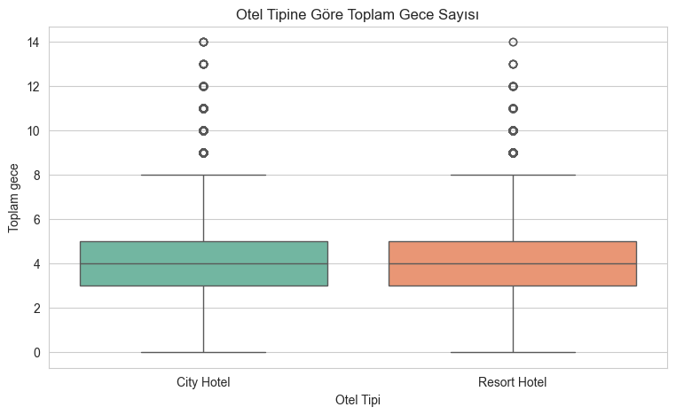

```python
fig, ax = plt.subplots(figsize=(9, 5))
sns.boxplot(data=df[df["toplam_gece"] <= 14], x="hotel", y="toplam_gece", hue="hotel", legend=False, ax=ax, palette="Set2")
ax.set_title("Otel Tipine Göre Toplam Gece Sayısı")
ax.set_xlabel("Otel Tipi")
ax.set_ylabel("Toplam gece")
plt.show()
```

### 5.3. İlk 10 Ülke — Rezervasyon Sayısı (Çubuk Grafik)

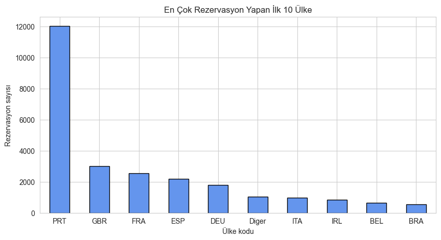

```python
fig, ax = plt.subplots(figsize=(10, 5))
top10.plot(kind="bar", ax=ax, color="cornflowerblue", edgecolor="black")
ax.set_title("En Çok Rezervasyon Yapan İlk 10 Ülke")
ax.set_ylabel("Rezervasyon sayısı")
ax.set_xlabel("Ülke kodu")
plt.xticks(rotation=0)
plt.show()
```

**Yorum:** Portekiz açık ara birinci gözüküyor. İkinci sıradaki İngiltere ile arada büyük fark var. Bu beklenen bir durum çünkü veri seti Portekiz'deki otellere ait olduğundan yerli müşteri pazarın büyük kısmını oluşturuyor. Yabancı turist pazarı düşünüldüğünde GBR, FRA, ESP, DEU dörtlüsü öne çıkıyor.

### 5.4. Ülkelere Göre İptal Oranı

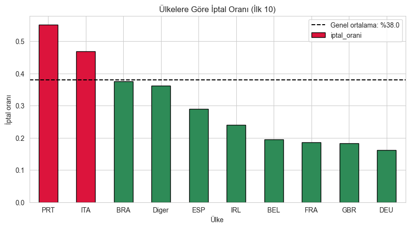

```python
iptal_grafik = ulke_ozet["iptal_orani"].sort_values(ascending=False)

fig, ax = plt.subplots(figsize=(10, 5))
colors = ["crimson" if v > 0.4 else "seagreen" for v in iptal_grafik.values]
iptal_grafik.plot(kind="bar", ax=ax, color=colors, edgecolor="black")
ax.set_title("Ülkelere Göre İptal Oranı (İlk 10)")
ax.set_ylabel("İptal oranı")
ax.set_xlabel("Ülke")
ax.axhline(df["is_canceled"].mean(), color="black", linestyle="--",
           label=f"Genel ortalama: %{df['is_canceled'].mean()*100:.1f}")
ax.legend()
plt.xticks(rotation=0)
plt.show()
```

### 5.5. Ülkelere Göre Ortalama ADR (Çubuk Grafik)

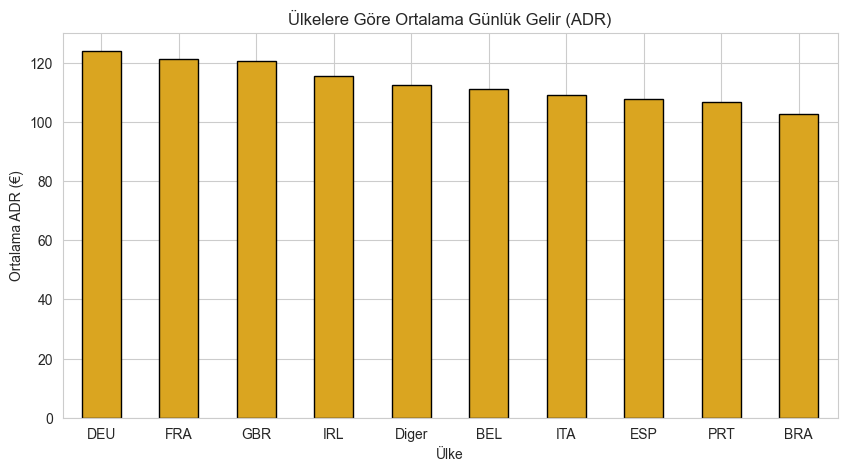

```python
adr_grafik = ulke_ozet["ortalama_adr"].sort_values(ascending=False)

fig, ax = plt.subplots(figsize=(10, 5))
adr_grafik.plot(kind="bar", ax=ax, color="goldenrod", edgecolor="black")
ax.set_title("Ülkelere Göre Ortalama Günlük Gelir (ADR)")
ax.set_ylabel("Ortalama ADR (€)")
ax.set_xlabel("Ülke")
plt.xticks(rotation=0)
plt.show()
```

### 5.6. Lead Time ile İptal İlişkisi (Saçılım Grafiği)

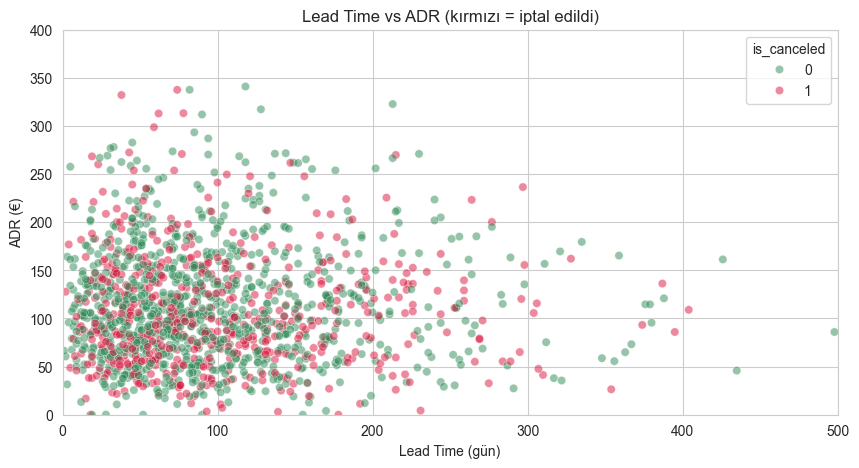

```python
# Rastgele 1500 örnek alıp grafikte boğulma yaşamayalım
ornek = df.sample(1500, random_state=1)

fig, ax = plt.subplots(figsize=(10, 5))
sns.scatterplot(
    data=ornek, x="lead_time", y="adr",
    hue="is_canceled", palette={0: "seagreen", 1: "crimson"},
    alpha=0.5, ax=ax
)
ax.set_title("Lead Time vs ADR (kırmızı = iptal edildi)")
ax.set_xlabel("Lead Time (gün)")
ax.set_ylabel("ADR (€)")
ax.set_xlim(0, 500)
ax.set_ylim(0, 400)
plt.show()
```

### 5.7. Korelasyon Isı Haritası

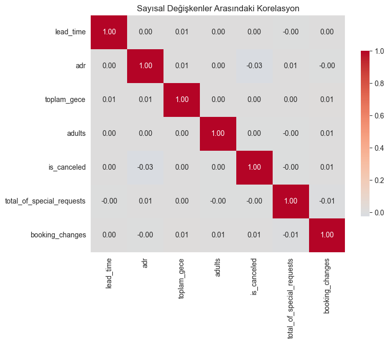

```python
fig, ax = plt.subplots(figsize=(8, 6))
sns.heatmap(df[sayisal].corr(), annot=True, cmap="coolwarm",
            center=0, fmt=".2f", ax=ax, cbar_kws={"shrink": 0.7})
ax.set_title("Sayısal Değişkenler Arasındaki Korelasyon")
plt.show()
```

**Yorum:** Korelasyon katsayıları oldukça düşük görünmektedir. Bu nedenle değişkenler arasında güçlü doğrusal ilişkiler gözlenmemektedir.

### 5.8. Ülke ve Otel Tipi Etkisi (Gruplanmış Çubuk)

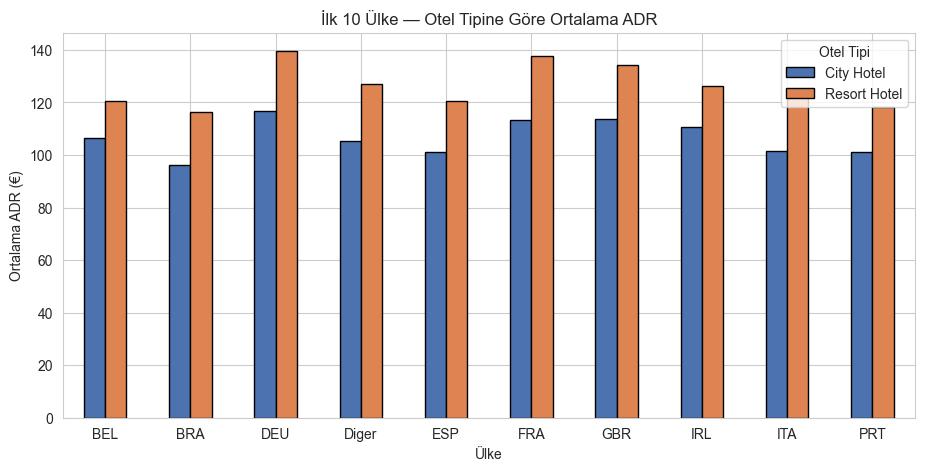

```python
karsilastirma = df_top.groupby(["country", "hotel"])["adr"].mean().unstack()

fig, ax = plt.subplots(figsize=(11, 5))
karsilastirma.plot(kind="bar", ax=ax, edgecolor="black", color=["#4C72B0", "#DD8452"])
ax.set_title("İlk 10 Ülke — Otel Tipine Göre Ortalama ADR")
ax.set_ylabel("Ortalama ADR (€)")
ax.set_xlabel("Ülke")
plt.xticks(rotation=0)
plt.legend(title="Otel Tipi")
plt.show()
```

**Yorum:** Resort Hotel'de ADR neredeyse her ülkede City Hotel'den daha yüksek. Tatil amaçlı müşteri daha çok harcıyor. Yurt dışında otel açılacaksa bunun bir kıyı/resort konseptli olması gelir açısından daha avantajlı görünüyor.

## 6. Ülke Bazlı Kârlılık Skoru

Tek bir kritere değil birkaç kritere birden bakmak için basit bir karşılaştırma tablosu yaparak her ülke için tahmini "müşteri başına gelir" hesaplandı:

> **Tahmini müşteri başına gelir** = Ortalama ADR × Ortalama Gece Sayısı × (1 - İptal Oranı)

İptal eden müşteri otele gelir bırakmadığı için iptal oranını çıkartılıyor. Bu kesin bir kâr hesabı değil sadece ülkeleri yan yana karşılaştırmak için bir yaklaşım. Gerçek kâr için maliyet, vergi vs. de hesaba katılmalı fakat bu veride o bilgiler bulunmuyor.

```python
ulke_ozet["tahmini_musteri_basina_gelir"] = (
    ulke_ozet["ortalama_adr"] *
    ulke_ozet["ortalama_gece"] *
    (1 - ulke_ozet["iptal_orani"])
).round(2)

ulke_skor = ulke_ozet.sort_values("tahmini_musteri_basina_gelir", ascending=False)
ulke_skor
```

| country | rezervasyon_sayisi | iptal_orani | ortalama_adr | ortalama_gece | tahmini_musteri_basina_gelir |
| --- | --- | --- | --- | --- | --- |
| DEU | 1802 | 0.162 | 123.923 | 4.133 | 429.20 |
| GBR | 3005 | 0.183 | 120.467 | 4.169 | 410.32 |
| FRA | 2559 | 0.186 | 121.284 | 4.128 | 407.54 |
| BEL | 635 | 0.195 | 111.190 | 4.198 | 375.75 |
| IRL | 837 | 0.240 | 115.483 | 4.165 | 365.55 |
| ESP | 2190 | 0.289 | 107.653 | 4.223 | 323.23 |
| Diger | 1040 | 0.362 | 112.407 | 4.163 | 298.55 |
| BRA | 548 | 0.376 | 102.706 | 4.000 | 256.35 |
| ITA | 975 | 0.468 | 109.070 | 4.138 | 240.11 |
| PRT | 12033 | 0.551 | 106.758 | 4.110 | 197.01 |

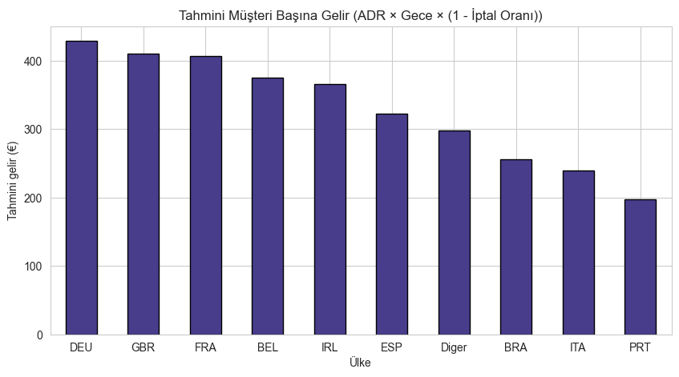

```python
fig, ax = plt.subplots(figsize=(10, 5))
ulke_skor["tahmini_musteri_basina_gelir"].plot(
    kind="bar", ax=ax, color="darkslateblue", edgecolor="black"
)
ax.set_title("Tahmini Müşteri Başına Gelir (ADR × Gece × (1 - İptal Oranı))")
ax.set_ylabel("Tahmini gelir (€)")
ax.set_xlabel("Ülke")
plt.xticks(rotation=0)
plt.show()
```

**Yorum:** Liste başında Almanya, İngiltere ve Fransa gibi ülkeler var. Portekiz tablonun en altlarında görünüyor. Yüksek iptal oranı, gelir potansiyelini ciddi şekilde düşürüyor. Yani çok müşteri olsa bile gerçekten otele gelip para bırakan müşteri sayısı az.

## 7. Sonuçlar ve İçgörüler

Analizler sonucunda şu çıkarımlar yapılabilir:

**1. Pazar büyüklüğü tek başına yeterli değil.** Portekiz veri setinde en kalabalık pazar olmasına rağmen iptal oranı %50'nin üzerinde. Bu da rezervasyonların yarısının gelire dönüşmediği anlamına geliyor. Müşteri kalabalığına bakıp karar vermek yanıltıcı olabilir.

**2. Almanya, İngiltere ve Fransa en dengeli pazarlar.** Bu ülkelerin rezervasyon sayısı yüksek, iptal oranları düşük (%17-20 civarı) ve ADR'leri ortalamanın üzerinde. Tahmini müşteri başına gelir sıralamasında bu üç ülke en üstlerde. Eğer hedef kitle seçmek gerekirse, Almanya'yı öne çıkarabiliriz: iptal oranı en düşük, ADR'si yüksek, rezervasyon hacmi normal.

**Genel öneri:** Verilere bakıldığında veri seti doğrudan hangi ülkede otel açılması gerektiğini göstermemektedir. Ancak Portekiz'deki oteller açısından değerlendirildiğinde Alman, İngiliz ve Fransız müşterilerin daha yüksek gelir potansiyeli sunduğu görülmektedir.

## 8. Sınırlılıklar

- Veri seti 2015-2017 yıllarını kapsıyor. Fakat pandemi sonrası turizm davranışı değiştiğinden dolayı bugün için doğrudan kullanılamayabilir.
- Maliyet, vergi, personel gideri gibi bilgiler veri setinde yok. Bu yüzden "kârlılık" değil, "gelir potansiyeli" üzerinden analiz yapıldı.
- ADR para birimi Euro olabilir fakat veri setinde net olarak belirtilmemiş.